# Структура научной презентации

Чилеше . Л

Российский университет дружбы народов, Москва, Россия

Объединённый институт ядерных исследований, Дубна, Россия

# Информация

## Докладчик

- Лупупа Чилеше
- Студент
- Студеднт Группы НПИбд-03-23
- Российский университет дружбы народов

# Вводная часть

## Цель работы

Получение навыков настройки базовых и специальных прав доступа для групп пользователей в операционной системе типа Linux.

## Задание

- Прочитайте справочное описание man по командам chgrp, chmod, getfacl, setfacl.
- Выполните действия по управлению базовыми разрешениями для групп пользователей (раздел 3.3.1).
- Выполните действия по управлению специальными разрешениями для групп пользователей (раздел 3.3.2). 4. Выполните действия по управлению расширенными разрешениями с использованием списков ACL для групп пользователей (раздел 3.3.3).

## терминал с учётной записью root:

su -

## /data/main и /data/third mkdir -p

- В корневом каталоге создайте каталоги /data/main и /data/third mkdir -p /data/main /data/third Посмотрите, кто является владельцем этих каталогов. Для этого используйте: ls -Al /data

## chgrp main /data/main chgrp third/data/third

- Прежде чем устанавливать разрешения, измените владельцев этих катало- гов с root на main и third соответственно: chgrp main /data/main chgrp third /data/third Посмотрите, кто теперь является владельцем этих каталогов: ls -Al /data

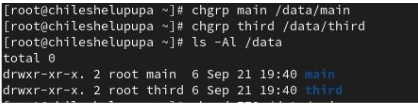

##сhmod 770 /data/main chmod 770/data/third

- Установите разрешения, позволяющие владельцам каталогов записывать файлы в эти каталоги и запрещающие доступ к содержимому каталогов всем другим пользователям и группам: chmod 770 /data/main chmod 770 /data/third Проверьте установленные права доступа.

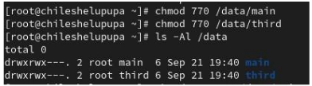

## su - bob

В другом терминале перейдите под учётную запись пользователя bob su - bob

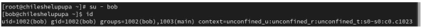

## ls -Al

- Под пользователем bob попробуйте перейти в каталог /data/main и создать
- файл emptyfile в этом каталог cd /data/main touch emptyfile ls -Al

[figure not shown]

## перейти в каталог /data/third

- Под пользователем bob попробуйте перейти в каталог /data/third и создать файл emptyfile в этом каталоге.

[figure not shown]

## alice

- Откройте новый терминал под пользователем alice

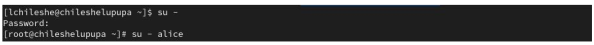

## touch alice1 touch alice2

- Перейдите в каталог /data/main cd /data/main Создайте два файла, владель- цем которых является alice: touch alice1 touch alice2

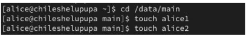

## Перейдите в каталог /data/main: cd /data/main и в этом каталоге введите: ls -l

[figure not shown]

## chmod g+s,o+t /data/main

- В терминале под пользователем root установите для каталога /data/main бит идентификатора группы, а также stiky-бит для разделяемого (общего) каталога группы: chmod g+s,o+t /data/main

## touch alice3 touch alice4 ls -l

- В терминале под пользователем alice создайте в каталоге /data/main файлы alice3 и alice4: touch alice3 touch alice4 ls -l

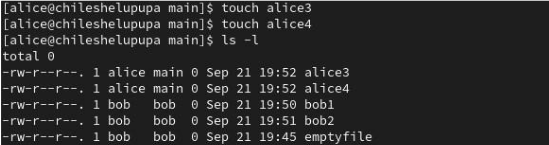

## “Hello, world”

- Для проверки полномочий группы third в каталоге /data/third войдите в другом терминале под учётной записью члена группы third: su - carol Про- верьте операции с файлами: rm /data/main/newfile1 rm /data/main/newfile2 Проверьте, возможно ли осуществить запись в файл: echo “Hello, world” » /data/main/newfile1 echo “Hello, world” » /data/main/newfile2

## “Hello, world”

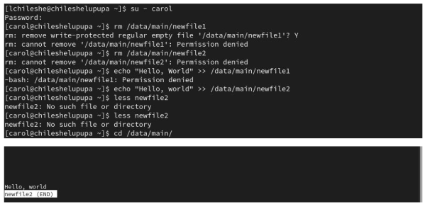

## Выводы

Я изучил получение функций для установки основных и специальных прав доступа для групп пользователей в таких системах, как Linux.